# Intro2R

# Intro2R part x: Puting it all together using Functions

To get the most out of R you will need to learn how to make functions. This will allow you to efficiently repeat the same analysis on different data and perfect your procedures.

Better yet you should package your functions so that improvements and new editions can be easily made to keep abreast of what you and others have learnt. You can also more easily share your work with others.

## Making functions

Every function is made using the following structure

```r
myf <- function(){

}
```

The function has a name – in this case `myf` and is created using the base R function `function()` inside the `()` parentheses you can place arguments then come the braces `{}` where you can place the body of the function which will contain formulae and R code to manipulate the data or variables supplied.

Typically we release a `list` to the command line.

A first function has been made for you

```r
myfirstfun
```

```
#> function (x, ...)
#> {
#>     y <- x^2
#>     graphics::plot(x, y, main = "My first R function", ...)
#>     return(list(x = x, y = y))
#> }
#> <bytecode: 0x7f98df60e718>
#> <environment: namespace:Intro2R>
```

This function takes a vector and makes a y vector equal to $x^2$ and then plots `y~x`.

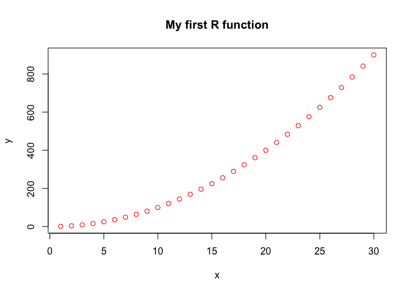

```
#> $x
#>  [1]  1  2  3  4  5  6  7  8  9 10 11 12 13 14 15 16 17 18 19 20 21 22 23 24 25
#> [26] 26 27 28 29 30
#>
#> $y
#>  [1]   1   4   9  16  25  36  49  64  81 100 121 144 169 196 225 256 289 324 361
#> [20] 400 441 484 529 576 625 676 729 784 841 900
```

```r
myfirstfun(x = 1:30, col = "Red")
```

Can you see what this function does? Notice that there is a list containing the `x` and `y` vectors.

We could catch the output in an object

```r
obj <- myfirstfun(x = 1:30, col = "Red")
```

[figure not shown]

```r
obj$x
```

```
#>  [1]  1  2  3  4  5  6  7  8  9 10 11 12 13 14 15 16 17 18 19 20 21 22 23 24 25
#> [26] 26 27 28 29 30
```

## Improve the function

We will improve the function by adding a better graph using ggplot and place a summary of the data frame

```r
myimprovedfun <- function(x, ...) { # key function "function(), name of function , ... sends extra arguments to plot
  y <- x^2 #object on the right x^2,  name on the left "y"
  df <- data.frame(x=x, y= y)
  g <- ggplot(df)
  g <- g + geom_point(aes(x = x, y=y, ...)) + ggtitle("Improved function")
  print(g)
  return(list(x=x,y=y, sumdf = summary(df))) # return will stop execution of code and release argument to the command line
}
```

Now call it

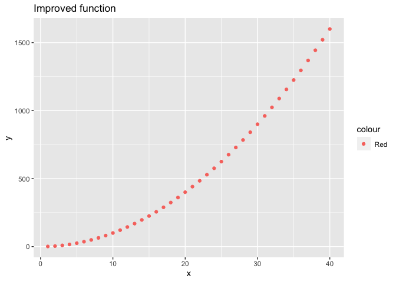

```
#> $x
#>  [1]  1  2  3  4  5  6  7  8  9 10 11 12 13 14 15 16 17 18 19 20 21 22 23 24 25
#> [26] 26 27 28 29 30 31 32 33 34 35 36 37 38 39 40
#>
#> $y
#>  [1]    1    4    9   16   25   36   49   64   81  100  121  144  169  196  225
#> [16]  256  289  324  361  400  441  484  529  576  625  676  729  784  841  900
#> [31]  961 1024 1089 1156 1225 1296 1369 1444 1521 1600
#>
#> $sumdf
#>        x               y
#>  Min.   : 1.00   Min.   :   1.0
#>  1st Qu.:10.75   1st Qu.: 115.8
#>  Median :20.50   Median : 420.5
#>  Mean   :20.50   Mean   : 553.5
#>  3rd Qu.:30.25   3rd Qu.: 915.2
#>  Max.   :40.00   Max.   :1600.0
```

```r
myimprovedfun(x = 1:40, col = "Red" )
```